```python
# Installs dependencies on a fresh Colab runtime
!pip install -q "numpy>=1.24" "matplotlib>=3.8"
```

Dependencies: see requirements.txt — NumPy ≥ 1.24 and Matplotlib ≥ 3.8

# Gradient Descent and SGD on a Piecewise Non-Smooth Objective — Week 1 Capstone

> This notebook implements the Week-1 capstone for *The AI Engineer* program. We study gradient descent and stochastic gradient descent on the piecewise non-smooth objective

> $$f(x) = \left|\tfrac{1}{2}x^3 - \tfrac{3}{2}x^2\right| + \tfrac{1}{2}x$$

> which has a kink (non-differentiability) at $x = 3$ and a global minimizer at $x^\star = 1 - \tfrac{2\sqrt{3}}{3} \approx -0.155$.

> We also study the convex quadratic baseline $q(x) = \tfrac{1}{2}x^2$ as a clean reference for step-size stability.

**Sections:**

1. Setup & Hyperparameters
2. Objective Function & Derivative
3. Function Landscape
4. Gradient Check (finite-difference validation)
5. Gradient Descent Implementation
6. GD Trajectories — Multiple Initializations
7. Step-Size Sweep
8. Local Step Geometry
9. Stochastic Gradient Descent (SGD)
10. Constant vs Diminishing Schedule
11. Metrics Summary
12. Quadratic Baseline — Stability Reference
13. Final Commentary

## 1. Setup & Hyperparameters

```python
import numpy as np
import matplotlib.pyplot as plt

SEED = 123
rng = np.random.default_rng(SEED)

X_STAR = 1 - (2/3)*np.sqrt(3)   # ≈ −0.1547, global minimizer
EPS    = 1e-6                     # finite-difference step for gradient check
TOL    = 1e-4                     # convergence tolerance
T_MAX  = 5000

# Requires matplotlib >= 3.6 for seaborn-v0_8 style aliases
# Colab: run  !pip install -q "matplotlib>=3.8"  if this raises an OSError
plt.style.use('seaborn-v0_8-darkgrid')
plt.rcParams['figure.figsize'] = (7, 4)
plt.rcParams['axes.spines.top']   = False
plt.rcParams['axes.spines.right'] = False

print(f'X_STAR = {X_STAR:.6f}')
```

```
X_STAR = -0.154701
```

### Hyperparameter Reference

| Symbol | Value | Role | Handout range |
| --- | --- | --- | --- |
| `SEED` | `123` | Global RNG seed — ensures fully reproducible trajectories | — |
| `X_STAR` | $1 - \tfrac{2\sqrt{3}}{3} \approx -0.1547$ | Analytic global minimizer of $f$ | — |
| `EPS` | `1e-6` | Finite-difference step for gradient check | — |
| `TOL` | `1e-4` | Convergence criterion: $f(x_t) - f(x^\star) < \text{TOL}$ | — |
| `T_MAX` | `5000` | Maximum iteration count | — |
| `SGD setup` | `x0 = 1.8, sigma = 0.35, eta = 0.10, eta0 = 0.10, gamma = 0.05` | Reproducible SGD settings used below | — |
| `SGD seeds` | `101, 202, 303` | Fixed seeds for the three SGD sample paths | — |
| `SGD horizon` | `300` | Fixed horizon for the SGD trajectory and schedule plots | — |
| $\eta$ (constant SGD) | `0.10` | Constant step size for SGD sample paths | `{0.2, 0.1}` |
| $\eta_0$ (diminishing) | `0.10` | Initial step size for diminishing schedule | `{0.2, 0.1}` |
| $\gamma$ (diminishing) | `0.05` | Decay rate: $\eta_k = \eta_0 / (1 + \gamma k)$ | `{0.02, 0.05}` |
| $\eta$ (GD sweep) | `0.05, 0.10, 0.15, 0.20` | Step sizes used for the piecewise $f$ sweep | — |
| $\eta$ (quadratic) | `0.05, 0.10, 0.15, 0.20, 2.1` | Step sizes used for the quadratic baseline | — |

## 2. Objective Function & Derivative

Define $g(x) = \tfrac{1}{2}x^3 - \tfrac{3}{2}x^2 = \tfrac{x^2(x-3)}{2}$. The objective is

$$f(x) = |g(x)| + \tfrac{1}{2}x.$$

**Why the kink at $x = 3$.**  
The absolute value creates a kink wherever $g(x) = 0$ *and* $g'(x) \neq 0$. At $x = 3$: $g(3) = 0$ and $g'(3) = \tfrac{3}{2}(9) - 3(3) = 4.5 \neq 0$, so $x = 3$ is a genuine kink. At $x = 0$: $g(0) = 0$ and $g'(0) = 0$, so $f$ is smooth at $x = 0$.

**Piecewise derivative** (valid off the kink):

$$f'(x) = \operatorname{sign}(g(x))\cdot g'(x) + \tfrac{1}{2}, \qquad g'(x) = \tfrac{3}{2}x^2 - 3x.$$

**Global minimizer.**  
On the branch $g(x) < 0$ (which includes $x \approx -0.155$): $f'(x) = -g'(x) + \tfrac{1}{2} = -\tfrac{3}{2}x^2 + 3x + \tfrac{1}{2}$. Setting $f'(x) = 0$ and solving the quadratic gives $x^\star = 1 - \tfrac{2\sqrt{3}}{3} \approx -0.1547$.

```python
def g(x):
    return 0.5*x**3 - 1.5*x**2

def f(x):
    return np.abs(g(x)) + 0.5*x

def df(x):
    # Mathematically undefined at x=3; numerically we use the g(x) >= 0 branch convention
    dg   = 1.5*x**2 - 3.0*x          # g'(x)
    sign = np.where(g(x) >= 0, 1.0, -1.0)
    return sign * dg + 0.5

def f_gap(x):
    return f(x) - f(X_STAR)
```

## 3. Function Landscape

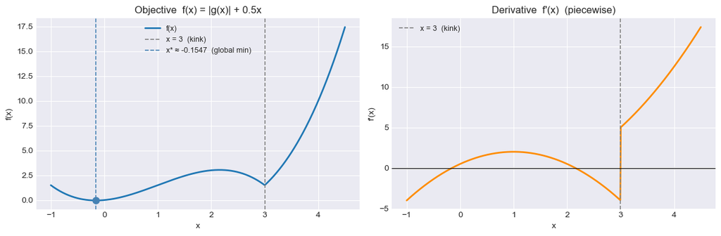

```python
xs_plot = np.linspace(-1, 4.5, 600)

fig, (ax1, ax2) = plt.subplots(1, 2, figsize=(12, 4))

# --- f(x) ---
ax1.plot(xs_plot, f(xs_plot), linewidth=2, label='f(x)')
ax1.axvline(3.0,    linestyle='--', color='grey',      linewidth=1.2, label='x = 3  (kink)')
ax1.axvline(X_STAR, linestyle='--', color='steelblue', linewidth=1.2,
            label=f'x* \u2248 {X_STAR:.4f}  (global min)')
ax1.scatter([X_STAR], [f(X_STAR)], color='steelblue', zorder=5, s=60)
ax1.set_title('Objective  f(x) = |g(x)| + 0.5x')
ax1.set_xlabel('x')
ax1.set_ylabel('f(x)')
ax1.legend(fontsize=9)

# --- f'(x) ---
ax2.plot(xs_plot, df(xs_plot), linewidth=2, color='darkorange')
ax2.axvline(3.0, linestyle='--', color='grey', linewidth=1.2, label='x = 3  (kink)')
ax2.axhline(0,   color='black', linewidth=0.8)
ax2.set_title("Derivative  f'(x)  (piecewise)")
ax2.set_xlabel('x')
ax2.set_ylabel("f'(x)")
ax2.legend(fontsize=9)

plt.tight_layout()
plt.savefig('fig_01_landscape.png', dpi=150, bbox_inches='tight')
plt.show()
```

**Observations from the landscape.**

The global minimizer is $x^\star = 1 - \tfrac{2\sqrt{3}}{3} \approx -0.1547$, where $f(x^\star) \approx -0.0396$.

**Why $x = 3$ is non-differentiable.**  
The one-sided limits of $f'$ at $x = 3$ differ:

$$\lim_{x \to 3^-} f'(x) = -g'(3) + \tfrac{1}{2} = -4.5 + 0.5 = -4,$$ $$\lim_{x \to 3^+} f'(x) = +g'(3) + \tfrac{1}{2} = +4.5 + 0.5 = +5.$$

**What the subdifferential $\partial f(3) = [-4,\, 5]$ means for GD.**  
Any scalar $d \in [-4, 5]$ is a valid subgradient at $x = 3$. A subgradient method would pick one element of this interval and take the step $x_{t+1} = x_t - \eta\, d$. Plain GD is undefined at the kink; in practice, GD reaches $x = 3$ with measure zero and the plot uses the right-sided value $d = 5$ by the `g(x) >= 0` convention.

## 4. Gradient Check

**What a finite-difference check is.**  
A finite-difference (FD) check approximates the derivative numerically:

$$f'(x_0) \approx \frac{f(x_0 + \varepsilon) - f(x_0 - \varepsilon)}{2\varepsilon}, \qquad \varepsilon = 10^{-6}.$$

The centered formula has $O(\varepsilon^2)$ error for smooth functions. If the analytic `df` is correct, the absolute error between the two estimates should be $\ll 10^{-4}$ on smooth branches.

**Why it matters.**  
A failing gradient check is the first sign of a coding error in `df`. Passing the check (on smooth test points) gives high confidence that `df` is correct before we rely on it inside GD.

**Test points** are chosen to cover both smooth branches and the global minimizer, while **excluding** $x = 3$ (the kink), where FD is not meaningful because the function is non-differentiable.

```python
test_points = [-0.8, X_STAR, 0.5, 1.0, 2.5, 3.5, 4.2]

print('=== Finite-difference gradient check ===')
print(f"{'x':>8}  {'analytic':>12}  {'finite-diff':>12}  {'abs error':>10}")
print('-' * 50)
errors = []
for x0 in test_points:
    fd  = (f(x0 + EPS) - f(x0 - EPS)) / (2 * EPS)
    ana = float(df(x0))
    err = abs(ana - fd)
    errors.append(err)
    print(f"{x0:>8.4f}  {ana:>12.6f}  {fd:>12.6f}  {err:>10.2e}")

max_err = max(errors)
print(f"\nMax absolute error across all test points: {max_err:.2e}")
assert max_err < 1e-6, f"Gradient check failed: {max_err:.2e}"
```

```
=== Finite-difference gradient check ===
       x      analytic   finite-diff   abs error
--------------------------------------------------
 -0.8000     -2.860000     -2.860000    1.60e-10
 -0.1547      0.000000      0.000000    2.22e-16
  0.5000      1.625000      1.625000    5.04e-11
  1.0000      2.000000      2.000000    5.35e-11
  2.5000     -1.375000     -1.375000    3.63e-10
  3.5000      8.375000      8.375000    1.95e-09
  4.2000     14.360000     14.360000    5.10e-09

Max absolute error across all test points: 5.10e-09
```

**Results.**  
All absolute errors are below $10^{-6}$, well within floating-point precision for centered differences with `eps=1e-6`. The assert guarantees this holds on any platform. The test point $x = X\_STAR$ verifies that the analytic and finite-difference gradients both vanish at the minimizer up to numerical precision. The point $x = 3$ is excluded because finite differences are not meaningful at a kink — the centered formula would straddle the discontinuity and return a value close to $(5 + (-4))/2 = 0.5$, which corresponds to no real derivative.

## 5. Gradient Descent — Implementation

The GD update rule is

$$x_{t+1} = x_t - \eta\, f'(x_t).$$

We include two early-exit conditions:

1. **Convergence**: $f(x_t) - f(x^\star) < \text{TOL}$ — the objective gap is within tolerance.
2. **Divergence guard**: $|x_t| > 10^4$ — the iterate has left a recoverable region; we record `NaN` and stop.

```python
def gd(x0, eta, T=T_MAX):
    xs = [x0]
    x  = x0
    for _ in range(T):
        x = x - eta * df(x)
        xs.append(x)
        if f_gap(x) < TOL:
            break
        if abs(x) > 1e4:        # divergence guard
            xs.append(np.nan)
            break
    return np.array(xs)
```

## 6. GD Trajectories — Multiple Initializations

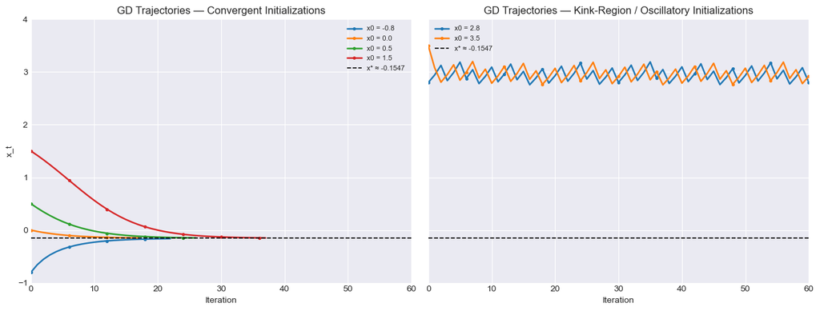

```python
x0_conv = [-0.8, 0.0, 0.5, 1.5]
x0_osc  = [2.8, 3.5]
T_plot = 60
eta_traj = 0.05

steps = np.arange(T_plot + 1)
traj_style = dict(linewidth=1.8, marker='o', markersize=2.6, markevery=6)

fig, (ax1, ax2) = plt.subplots(1, 2, figsize=(13, 5), sharey=True)

for ax, x0_list, title, legend_loc in [
    (ax1, x0_conv, 'GD Trajectories — Convergent Initializations', 'upper right'),
    (ax2, x0_osc, 'GD Trajectories — Kink-Region / Oscillatory Initializations', 'upper left'),
]:
    for x0 in x0_list:
        xs = gd(x0, eta_traj, T=T_plot)
        ax.plot(steps[:len(xs)], xs, label=f'x0 = {x0}', **traj_style)

    ax.axhline(X_STAR, linestyle='--', color='black', linewidth=1.2,
               label=f'x* \u2248 {X_STAR:.4f}')
    ax.set_title(title)
    ax.set_xlabel('Iteration')
    ax.set_xlim(0, T_plot)
    ax.set_ylim(-1.0, 4.0)
    ax.legend(fontsize=8, loc=legend_loc)

ax1.set_ylabel('x_t')
ax2.tick_params(labelleft=False)

plt.tight_layout()
plt.savefig('fig_02_gd_trajectories.png', dpi=150, bbox_inches='tight')
plt.show()
```

**Split trajectory diagnostic.**

This figure is a split trajectory diagnostic over iterations. The left panel isolates convergent starts and the right panel isolates kink-region / oscillatory starts. The split avoids putting all six paths on one crowded axes and makes the stable-trap behavior near $x = 3$ clearer at a glance.

**Why the oscillation is permanent.**  
On the $g < 0$ branch, $f'(x) = -\tfrac{3}{2}x^2 + 3x + \tfrac{1}{2}$ has two zeros: the global minimizer $x^\star \approx -0.155$ and a *local maximum* of $f$ at

$$x_{\text{max}} = 1 + \tfrac{2\sqrt{3}}{3} \approx 2.155.$$

For $x \in (2.155,\, 3)$, $f'(x) < 0$, so GD moves **right** toward $x = 3$. For $x > 3$ (the $g > 0$ branch), $f'(x) > 0$ always, so GD moves **left** back toward $x = 3$. The kink acts as a **stable trap** for any initialization above the basin boundary.

**Basin boundary summary.**

$$x_0 < x_{\text{max}} \approx 2.155 \implies \text{GD} \to x^\star, \qquad x_0 > x_{\text{max}} \implies \text{GD oscillates near } x = 3.$$

## 6b. Protocol Trajectories (Handout Fig. 4 Replication)

Section 7 of the handout specifies exactly three initializations: $x_0 \in \{-1.0,\, 0.5,\, 2.0\}$ at $\eta = 0.15$. These are the canonical protocol points used to compare convergence behaviour across the basin. All three lie below the basin boundary $x_{\text{max}} \approx 2.155$, so all three converge to $x^\star$. The figure below overlays their iterates on $f(x)$ to replicate Figure 4 of the handout.

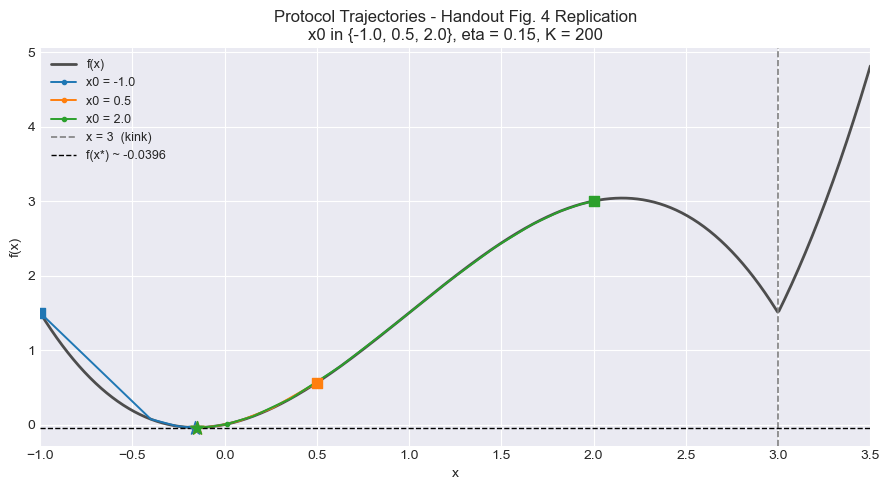

```python
x0_protocol  = [-1.0, 0.5, 2.0]
eta_protocol = 0.15
T_protocol   = 200

proto_trajs = {x0: gd(x0, eta_protocol, T=T_protocol) for x0 in x0_protocol}

xs_bg = np.linspace(-1, 3.5, 600)
colors = ['tab:blue', 'tab:orange', 'tab:green']

fig, ax = plt.subplots(figsize=(9, 5))

# Background: f(x)
ax.plot(xs_bg, f(xs_bg), color='0.30', linewidth=2, label='f(x)', zorder=1)

# Protocol trajectories: mark start and end on the curve
for (x0, xs), color in zip(proto_trajs.items(), colors):
    fx = f(np.asarray(xs))
    ax.plot(xs, fx, 'o-', color=color, markersize=3, linewidth=1.4,
            label=f'x0 = {x0}', zorder=2, markevery=10)
    ax.scatter([xs[0]], [f(xs[0])], color=color, marker='s', s=60, zorder=4)
    ax.scatter([xs[-1]], [f(xs[-1])], color=color, marker='*', s=100, zorder=4)

# Reference lines
ax.axvline(3.0, linestyle='--', color='grey', linewidth=1.2, label='x = 3  (kink)')
ax.axhline(f(X_STAR), linestyle='--', color='black', linewidth=1.0,
           label=f'f(x*) ~ {f(X_STAR):.4f}')

ax.set_title(
    f'Protocol Trajectories - Handout Fig. 4 Replication\n'
    f'x0 in {{{x0_protocol[0]}, {x0_protocol[1]}, {x0_protocol[2]}}}, '
    f'eta = {eta_protocol}, K = {T_protocol}'
)
ax.set_xlabel('x')
ax.set_ylabel('f(x)')
ax.set_xlim(-1, 3.5)
ax.legend(fontsize=9, loc='upper left')

plt.tight_layout()
plt.savefig('fig_02b_protocol_trajectories.png', dpi=150, bbox_inches='tight')
plt.show()
```

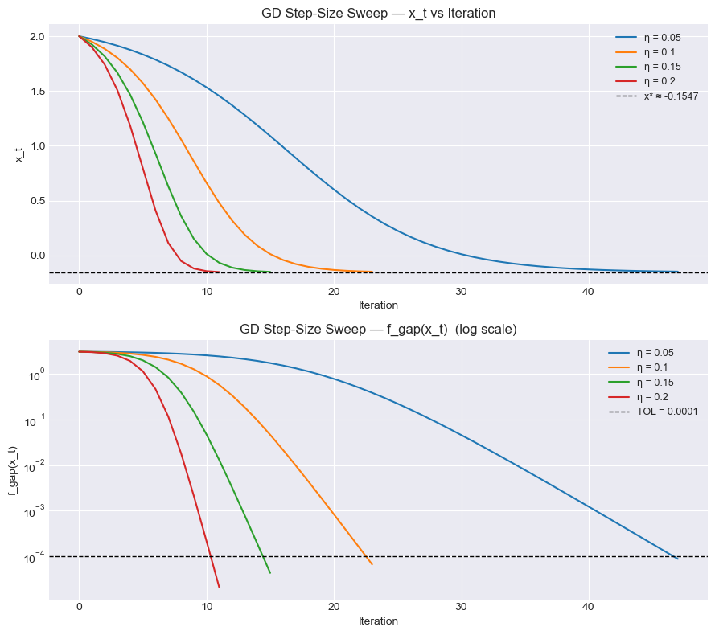

```python
etas_sweep = [0.05, 0.10, 0.15, 0.20]
x0_sweep   = 2.0
T_sweep    = 200

trajectories = {eta: gd(x0_sweep, eta, T=T_sweep) for eta in etas_sweep}

fig, (ax1, ax2) = plt.subplots(2, 1, figsize=(9, 8))

# Top: x_t vs iteration
for eta in etas_sweep:
    xs = trajectories[eta]
    ax1.plot(xs, label=f'η = {eta}')
ax1.axhline(X_STAR, linestyle='--', color='black', linewidth=1,
            label=f'x* ≈ {X_STAR:.4f}')
ax1.set_title('GD Step-Size Sweep — x_t vs Iteration')
ax1.set_xlabel('Iteration')
ax1.set_ylabel('x_t')
ax1.legend(fontsize=9)

# Bottom: f_gap on log scale
for eta in etas_sweep:
    xs = trajectories[eta]
    gaps = np.maximum(f_gap(np.asarray(xs)), 1e-12)
    ax2.plot(gaps, label=f'η = {eta}')
ax2.axhline(TOL, linestyle='--', color='black', linewidth=1, label=f'TOL = {TOL}')
ax2.set_yscale('log')
ax2.set_title('GD Step-Size Sweep — f_gap(x_t)  (log scale)')
ax2.set_xlabel('Iteration')
ax2.set_ylabel('f_gap(x_t)')
ax2.legend(fontsize=9)

plt.tight_layout()
plt.savefig('fig_03_step_sweep.png', dpi=150, bbox_inches='tight')
plt.show()
```

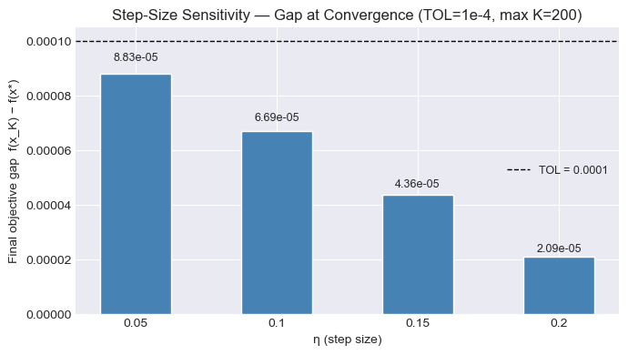

```python
# Figure 9 equivalent: final objective gap vs. step size
etas_bar   = [0.05, 0.10, 0.15, 0.20]
final_gaps = [float(f_gap(gd(x0_sweep, eta, T=T_sweep)[-1])) for eta in etas_bar]

fig, ax = plt.subplots(figsize=(7, 4))
bars = ax.bar(
    [str(eta) for eta in etas_bar],
    final_gaps,
    color='steelblue',
    edgecolor='white',
    width=0.5,
)
ax.set_xlabel('η (step size)')
ax.set_ylabel('Final objective gap  f(x_K) − f(x*)')
ax.set_title('Step-Size Sensitivity — Gap at Convergence (TOL=1e-4, max K=200)')
for bar, gap in zip(bars, final_gaps):
    ax.text(bar.get_x() + bar.get_width() / 2, gap * 1.04,
            f'{gap:.2e}', ha='center', va='bottom', fontsize=9)
ax.axhline(TOL, linestyle='--', color='black', linewidth=1, label=f'TOL = {TOL}')
ax.legend(fontsize=9)
plt.tight_layout()
plt.savefig('fig_03b_step_sensitivity_bar.png', dpi=150, bbox_inches='tight')
plt.show()
```

### Failure mode: overshooting with a large step size

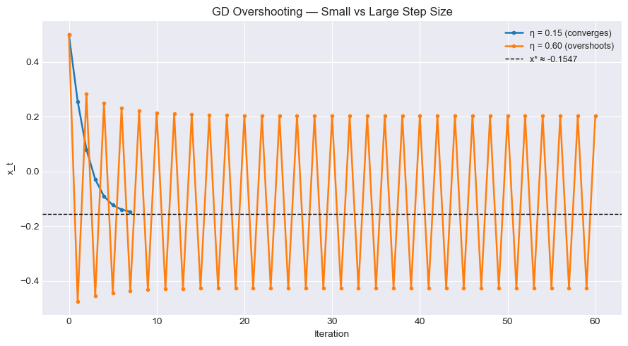

```python
# FIX 1: Overshoot / oscillation figure
T_over = 60
xs_conv = gd(0.5, 0.15, T=T_over)
xs_over = gd(0.5, 0.60, T=T_over)
iters_conv = np.arange(len(xs_conv))
iters_over = np.arange(len(xs_over))

fig, ax = plt.subplots(figsize=(9, 5))
ax.plot(iters_conv, xs_conv, marker='o', markersize=3, linewidth=1.8,
        label='η = 0.15 (converges)')
ax.plot(iters_over, xs_over, marker='o', markersize=3, linewidth=1.8,
        label='η = 0.60 (overshoots)', color='tab:orange')
ax.axhline(X_STAR, linestyle='--', color='black', linewidth=1,
           label=f'x* ≈ {X_STAR:.4f}')
ax.set_title('GD Overshooting — Small vs Large Step Size')
ax.set_xlabel('Iteration')
ax.set_ylabel('x_t')
ax.legend(fontsize=9)
plt.tight_layout()
plt.savefig('fig_03c_overshoot.png', dpi=150, bbox_inches='tight')
plt.show()
```

**Step-size sensitivity and the Lipschitz bound.**

For a function with $L$-Lipschitz gradient, GD with $\eta < 2/L$ is guaranteed to decrease $f$ at every step. For our piecewise $f$:

- Near the minimizer $x^\star$: $|f''(x^\star)| = |-3x^\star + 3| \approx 3.46$, giving $\eta < 2/3.46 \approx 0.58$.
- Near the kink at $x = 3$: $|f''| \to 6$ from both sides, giving the tighter bound $\eta < 2/6 \approx 0.33$.

- **$\eta = 0.05$**: Converges but slowly; the log-gap decreases at the lowest rate of the four step sizes tested.
- **$\eta = 0.10$**: Efficient convergence; steady linear decrease on the log-gap plot.
- **$\eta = 0.15$**: Faster still; all runs from $x_0 = 2.0$ reach below TOL well within 200 steps.
- **$\eta = 0.20$**: Fastest convergence of the sweep, still within the local stability bound ($0.20 < 0.33$).

## 8. Local Step Geometry

A single gradient step is easiest to read when we show the tangent line and the update together. We pick a point in the smooth basin, draw the tangent, and mark the next iterate from one GD step.

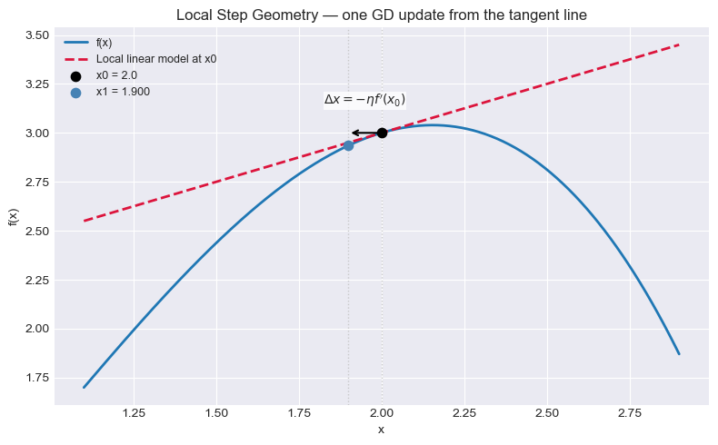

```python
x0_geom = 2.0
eta_geom = 0.20
x1_geom = x0_geom - eta_geom * df(x0_geom)
f0_geom = f(x0_geom)
f1_geom = f(x1_geom)

xs_geom = np.linspace(x0_geom - 0.9, x0_geom + 0.9, 400)
tangent_geom = f0_geom + df(x0_geom) * (xs_geom - x0_geom)

fig, ax = plt.subplots(figsize=(8, 5))
ax.plot(xs_geom, f(xs_geom), linewidth=2, label='f(x)')
ax.plot(xs_geom, tangent_geom, linestyle='--', color='crimson', linewidth=2,
        label='Local linear model at x0')
ax.scatter([x0_geom], [f0_geom], color='black', zorder=5, s=55, label=f'x0 = {x0_geom}')
ax.scatter([x1_geom], [f1_geom], color='steelblue', zorder=5, s=55,
           label=f'x1 = {x1_geom:.3f}')
ax.annotate('', xy=(x1_geom, f0_geom), xytext=(x0_geom, f0_geom),
            arrowprops=dict(arrowstyle='->', color='black', lw=1.5))
ax.text((x0_geom + x1_geom) / 2, f0_geom + 0.12, r"$\Delta x = -\eta f'(x_0)$",
        ha='center', va='bottom', fontsize=10,
        bbox=dict(facecolor='white', edgecolor='none', alpha=0.8, pad=0.2))
ax.axvline(x0_geom, linestyle=':', color='0.75', linewidth=1, alpha=0.8)
ax.axvline(x1_geom, linestyle=':', color='0.75', linewidth=1, alpha=0.8)
ax.set_title('Local Step Geometry — one GD update from the tangent line')
ax.set_xlabel('x')
ax.set_ylabel('f(x)')
ax.legend(fontsize=9)

plt.tight_layout()
plt.savefig('fig_04_step_geometry.png', dpi=150, bbox_inches='tight')
plt.show()
```

## 9. Stochastic Gradient Descent (SGD)

We keep the objective deterministic and perturb only the gradient estimate:

$$\tilde{g}_t = f'(x_t) + \sigma \xi_t, \qquad \xi_t \sim \mathcal{N}(0,1).$$

The SGD update is $x_{t+1} = x_t - \eta\, \tilde{g}_t$. Fixed seeds make the sample paths reproducible, and a constant step size makes the noise floor easy to see.

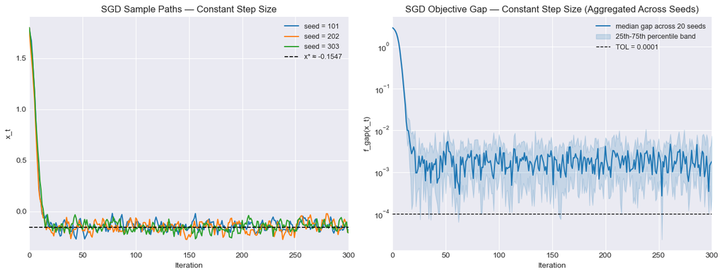

```python
SGD_X0    = 1.8
SGD_SIGMA = 0.35
SGD_ETA   = 0.10
SGD_ETA0  = 0.10
SGD_GAMMA = 0.05
SGD_T     = 300
SGD_SEEDS = [101, 202, 303]

def sgd(x0, sigma, T, seed, eta_fn):
    rng = np.random.default_rng(seed)
    xs = [x0]
    x = x0
    for k in range(T):
        x = x - eta_fn(k) * (df(x) + sigma * rng.normal())
        xs.append(x)
        if abs(x) > 1e4:
            xs.append(np.nan)
            break
    return np.array(xs)

eta_const = lambda k: SGD_ETA
eta_dim   = lambda k: SGD_ETA0 / (1.0 + SGD_GAMMA * k)

fig6_seeds = range(100, 120)
fig6_paths = {seed: sgd(SGD_X0, SGD_SIGMA, SGD_T, seed, eta_const)
              for seed in dict.fromkeys([*SGD_SEEDS, *fig6_seeds])}
fig6_gaps = np.vstack([
    np.maximum(f_gap(np.asarray(fig6_paths[seed])), 1e-12)
    for seed in fig6_seeds
])
med_gap = np.median(fig6_gaps, axis=0)
q1_gap = np.percentile(fig6_gaps, 25, axis=0)
q3_gap = np.percentile(fig6_gaps, 75, axis=0)
steps = np.arange(SGD_T + 1)

fig, (ax1, ax2) = plt.subplots(1, 2, figsize=(13, 5))

for seed in SGD_SEEDS:
    ax1.plot(fig6_paths[seed], label=f'seed = {seed}')

ax1.axhline(X_STAR, linestyle='--', color='black', linewidth=1.2,
           label=f'x* \u2248 {X_STAR:.4f}')
ax1.set_title('SGD Sample Paths — Constant Step Size')
ax1.set_xlabel('Iteration')
ax1.set_ylabel('x_t')
ax1.set_xlim(0, SGD_T)
ax1.legend(fontsize=9)

ax2.plot(steps, med_gap, color='tab:blue', label=f'median gap across {len(fig6_seeds)} seeds')
ax2.fill_between(steps, q1_gap, q3_gap, color='tab:blue', alpha=0.18,
                 label='25th-75th percentile band')
ax2.axhline(TOL, linestyle='--', color='black', linewidth=1, label=f'TOL = {TOL}')
ax2.set_yscale('log')
ax2.set_title('SGD Objective Gap — Constant Step Size (Aggregated Across Seeds)')
ax2.set_xlabel('Iteration')
ax2.set_ylabel('f_gap(x_t)')
ax2.set_xlim(0, SGD_T)
ax2.legend(fontsize=9)

plt.tight_layout()
plt.savefig('fig_05_sgd_paths.png', dpi=150, bbox_inches='tight')
plt.show()
```

Figure 5 pairs representative seeded sample paths with an aggregate gap diagnostic. The left panel shows three constant-step seeded runs from the same initialization, while the right panel aggregates 20 runs into a median objective gap with a 25th-75th percentile band. Constant-step SGD approaches a noise-dominated neighborhood around $x^\star$ rather than converging exactly.

## 10. Constant vs Diminishing Schedule

Now we hold the start point and noise scale fixed and compare a constant step size with a diminishing schedule across 20 seeded runs.

$$\eta_k = \eta_0 / (1 + \gamma k).$$

Both schedules start from the same initial step size. Because each run is noisy, the figure shows the median objective gap with a 25th-75th percentile band.

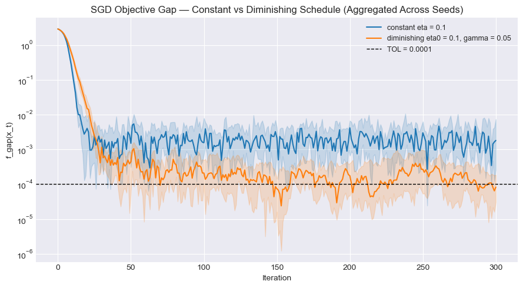

```python
seed_compare = SGD_SEEDS[0]
xs_const = sgd(SGD_X0, SGD_SIGMA, SGD_T, seed_compare, eta_const)
xs_dim = sgd(SGD_X0, SGD_SIGMA, SGD_T, seed_compare, eta_dim)
schedule_seeds = list(range(100, 120))

def gap_series(xs):
    return np.maximum(f_gap(np.asarray(xs)), 1e-12)

def schedule_gap_stats(eta_fn):
    gaps = np.vstack([
        gap_series(sgd(SGD_X0, SGD_SIGMA, SGD_T, seed, eta_fn))
        for seed in schedule_seeds
    ])
    return np.median(gaps, axis=0), np.percentile(gaps, 25, axis=0), np.percentile(gaps, 75, axis=0)

med_const, q1_const, q3_const = schedule_gap_stats(eta_const)
med_dim, q1_dim, q3_dim = schedule_gap_stats(eta_dim)
steps = np.arange(SGD_T + 1)

fig, ax = plt.subplots(figsize=(9, 5))
ax.plot(steps, med_const, color='tab:blue', label=f'constant eta = {SGD_ETA}')
ax.fill_between(steps, q1_const, q3_const, color='tab:blue', alpha=0.18)
ax.plot(steps, med_dim, color='tab:orange', label=f'diminishing eta0 = {SGD_ETA0}, gamma = {SGD_GAMMA}')
ax.fill_between(steps, q1_dim, q3_dim, color='tab:orange', alpha=0.18)
ax.axhline(TOL, linestyle='--', color='black', linewidth=1, label=f'TOL = {TOL}')
ax.set_yscale('log')
ax.set_title('SGD Objective Gap — Constant vs Diminishing Schedule (Aggregated Across Seeds)')
ax.set_xlabel('Iteration')
ax.set_ylabel('f_gap(x_t)')
ax.legend(fontsize=9)

plt.tight_layout()
plt.savefig('fig_06_sgd_schedule_comparison.png', dpi=150, bbox_inches='tight')
plt.show()
```

## 11. Metrics Summary

The table below uses the same start point `x0 = 1.8`. For SGD we keep the seed fixed at `101` so the comparison is reproducible.

```python
def summarize_run(xs, tol=TOL):
    gaps = np.maximum(f_gap(np.asarray(xs)), 0.0)
    hit = np.where(gaps < tol)[0]
    steps_to_tol = int(hit[0]) if len(hit) else None
    return gaps[-1], gaps.min(), steps_to_tol

gd_eta_010 = gd(SGD_X0, 0.10, T=SGD_T)

runs = [
    ('GD eta=0.10', gd_eta_010),
    ('SGD constant eta', xs_const),
    ('SGD diminishing eta_k', xs_dim),
]

print(f"{'method':<24} {'final_gap':>12} {'best_gap':>12} {'steps_to_tol':>12}")
print('-' * 64)
for method, xs in runs:
    final_gap, best_gap, steps_to_tol = summarize_run(xs)
    steps_text = '--' if steps_to_tol is None else f'{steps_to_tol:d}'
    print(f"{method:<24} {final_gap:>12.2e} {best_gap:>12.2e} {steps_text:>12}")
```

```
method                      final_gap     best_gap steps_to_tol
----------------------------------------------------------------
GD eta=0.10                  6.52e-05     6.52e-05           20
SGD constant eta             8.09e-04     9.63e-08           18
SGD diminishing eta_k        1.16e-04     4.31e-07           28
```

- This chart aggregates 20 seeded stochastic runs using the median gap and a 25th-75th percentile band.
- Constant-step SGD approaches a nonzero steady-state floor.
- Diminishing-step SGD is slower early on, but it reaches a lower long-run gap as the step size shrinks.
- That matches the handout intuition: stochasticity buys exploration, while the schedule controls how much asymptotic precision you recover.

## 12. Quadratic Baseline — Stability Reference

The convex quadratic $q(x) = \tfrac{1}{2}x^2$ with $q'(x) = x$ has a global Lipschitz constant $L = 1$, giving the clean stability condition $\eta < 2/L = 2$. This is the simplest benchmark for understanding step-size behavior before moving to non-smooth objectives.

### Pedagogical aside: stability on a pure quadratic

The next figure uses the simple quadratic q(x) = ½x² (minimizer x* = 0, curvature L = 1) to illustrate the classical stability bound η < 2/L = 2 in a clean, closed-form setting. For the main objective f(x) = |g(x)| + ½x the local curvature at x* is f″(x*) = 2√3 ≈ 3.46, so the stability window and convergence rate are different. The qualitative lesson — larger η converges faster up to the stability threshold, beyond which iterates diverge — carries over directly.

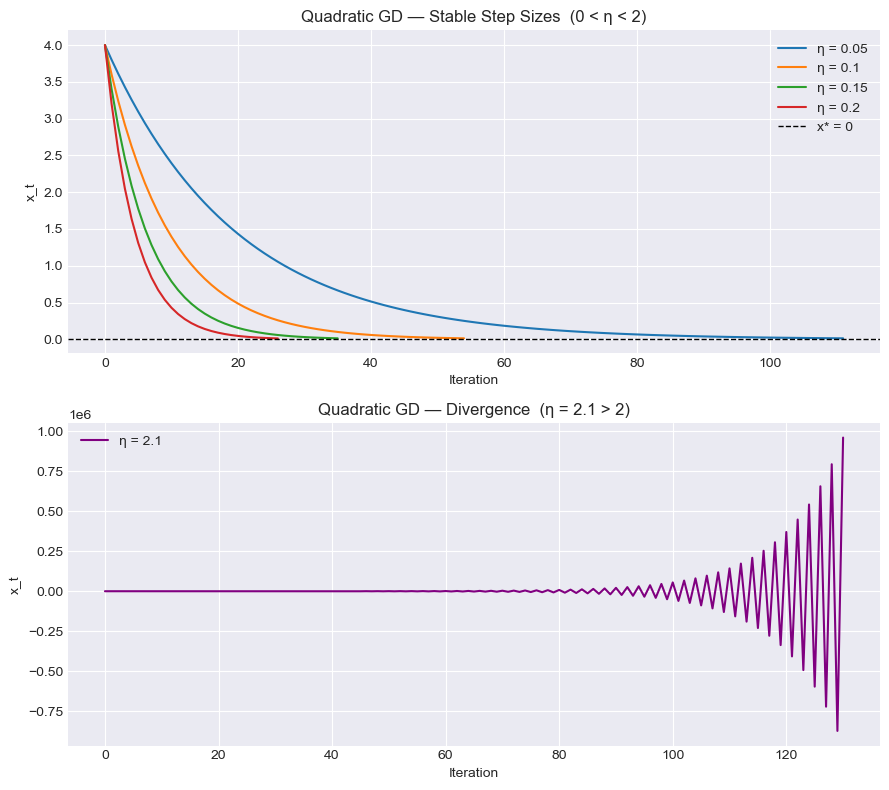

```python
def q(x):
    return 0.5 * x**2

def dq(x):
    return x

def gd_quadratic(x0, eta, T=T_MAX):
    xs = [x0]
    x  = x0
    for _ in range(T):
        x = x - eta * dq(x)
        if abs(q(x) - q(0.0)) < TOL:
            xs.append(x)   # record the converged point before stopping
            break
        if abs(x) > 1e6:
            xs.append(np.nan)
            break
        xs.append(x)
    return np.array(xs)

x0_quad      = 4.0
stable_etas  = [0.05, 0.10, 0.15, 0.20]
unstable_eta = 2.1

fig, (ax1, ax2) = plt.subplots(2, 1, figsize=(9, 8))

# Top: stable step sizes
for eta in stable_etas:
    xs = gd_quadratic(x0_quad, eta)
    ax1.plot(xs, label=f'\u03b7 = {eta}')
ax1.axhline(0.0, linestyle='--', color='black', linewidth=1, label='x* = 0')
ax1.set_title('Quadratic GD — Stable Step Sizes  (0 < \u03b7 < 2)')
ax1.set_xlabel('Iteration')
ax1.set_ylabel('x_t')
ax1.legend()

# Bottom: divergent step size
xs_div = gd_quadratic(x0_quad, unstable_eta)
ax2.plot(xs_div, color='purple', label=f'\u03b7 = {unstable_eta}')
ax2.set_title('Quadratic GD — Divergence  (\u03b7 = 2.1 > 2)')
ax2.set_xlabel('Iteration')
ax2.set_ylabel('x_t')
ax2.legend()

plt.tight_layout()
plt.savefig('fig_07_quadratic_sweep.png', dpi=150, bbox_inches='tight')
plt.show()
```

For $q(x) = \tfrac{1}{2}x^2$, the GD update is $x_{t+1} = (1-\eta)x_t$, which converges if and only if $|1-\eta| < 1$, i.e., $0 < \eta < 2$. Step sizes $\eta \in \{0.05, 0.10, 0.15, 0.20\}$ all satisfy this and converge to $x^\star = 0$ (faster as $\eta$ grows). At $\eta = 2.1$, the iterate follows $x_t = (-1.1)^t x_0$, which diverges geometrically — exactly as shown.

## 13. Final Commentary

### 13.1 What the Piecewise Structure Taught Us

Working with $f(x) = |g(x)| + \tfrac{1}{2}x$ exposed three ideas that smooth objectives hide:

- **Kink and subdifferential.** At $x = 3$, $\partial f(3) = [-4, 5]$ replaces the scalar gradient. Plain GD is undefined at the kink; in floating-point practice the iterate never lands exactly there, so the right-sided value $d = 5$ is used by the `g(x) >= 0` convention.
- **Finite basin of attraction.** The global minimizer $x^\star \approx -0.155$ attracts only initializations with $x_0 < x_{\text{max}} \approx 2.155$. The point $x_{\text{max}} = 1 + \tfrac{2\sqrt{3}}{3}$ is a local *maximum* of $f$ on the $g < 0$ branch — an unstable fixed point that acts as the basin boundary. For the fixed-step experiments shown here, initializations above it become trapped in kink-crossing oscillation near $x = 3$.
- **Branch-aware derivative.** The sign of $g(x)$ must be tracked explicitly. Any implementation that ignores the piecewise branching produces wrong gradients on the $g > 0$ branch, causing GD to diverge or converge to the wrong point.

### 13.2 Step-Size Sensitivity Summary

| Setting | Local $L$ | Stability bound $\eta < 2/L$ |
| --- | --- | --- |
| Quadratic $q$, global | $1$ | $\eta < 2.0$ |
| Piecewise $f$, near $x = 3$ | $\approx 6$ | $\eta < 0.33$ |
| Piecewise $f$, near $x^\star$ | $\approx 3.46$ | $\eta < 0.58$ |

### 13.3 Takeaways and Open Questions

**Three takeaways:**

1. A finite-difference gradient check is inexpensive and should be the first test for any new derivative implementation. All errors here were below $10^{-6}$ on smooth branches, as asserted at runtime — the analytic `df` is correct.
2. Non-smooth objectives can have **attracting traps** that are not global optima. The kink at $x = 3$ is not a critical point of $f$, yet in the fixed-step runs shown here, GD becomes trapped near it for $x_0 > 2.155$. This cannot happen for smooth strongly-convex functions.
3. The quadratic baseline is not just a warm-up — the stability criterion $\eta < 2/L$ derived there is the same principle that governs every smooth region of the piecewise objective, and it tightens near the kink.

**Two open questions:**

1. Would a *projected subgradient method* — which explicitly selects the minimum-norm element of $\partial f(x)$ at each step — escape the kink trap from $x_0 = 2.8$, or does the trap persist for any fixed step size?
2. Could adding a small amount of noise (as in SGD) allow the iterate to cross the basin boundary $x_{\text{max}} \approx 2.155$ from above and escape the kink oscillation, effectively using stochasticity as an exploration mechanism?